# ......................Project : Wrangle and Analyze Data ...................................

## prepared by : Shuaib Elamrity

### 3/7/2021

# Introduction

```
 Real-world data rarely comes clean. Using Python and its libraries, you will gather data from a variety of sources and in a variety of formats, assess its quality and tidiness, then clean it. This is called data wrangling. You will document your wrangling efforts in a Jupyter Notebook, plus showcase them through analyses and visualizations using Python (and its libraries) and/or SQL.
```

## Gathering Data

### The data consists of three different files

> 1.**Twitter archive file** : download this file manually by clicking the following link: twitter_archive_enhanced.csv

> 2.**The tweet image predicitions** : i.e., what breed of dog (or other object, animal, etc.) is present in each tweet according to a neural network. This file (image_predictions.tsv) is hosted on Udacity's servers and should be downloaded programmatically using the Requests library and the following URL: https://d17h27t6h515a5.cloudfront.net/topher/2017/August/599fd2ad_image-predictions/image-predictions.tsv

> 3.**Twitter API & JSON** : Each tweet's retweet count and favorite ("like") count at minimum, and any additional data you find interesting. Using the tweet IDs in the WeRateDogs Twitter archive, query the Twitter API for each tweet's JSON data using Python's Tweepy library and store each tweet's entire set of JSON data in a file called tweet_json.txt file. Each tweet's JSON data should be written to its own line. Then read this .txt file line by line into a pandas DataFrame with (at minimum) tweet ID, retweet count, and favorite count.

# Steps

1. Wrangle Data

   . Gathering data  
   . Assessing data  
   . Cleaning data
2. Storing the clean data
3. analyze and visualaize data
4. report the analizing data

### First : import the libraries that i will be using

```python
# import a statements and library
import pandas as pd
import numpy as np
import requests
import json
import time
import matplotlib.pyplot as plt
import os
import tweepy
import PIL.Image
from io import BytesIO
from PIL import Image
import matplotlib.pyplot as plt
import seaborn as sb
%matplotlib inline
```

# Secound : Gathering Data

#### First Data

```python
# first data is a csv on my computer
twitter_archive =pd.read_csv('twitter-archive-enhanced.csv')
```

```python
#read the data
twitter_archive.head(2)
```

|  | tweet_id | in_reply_to_status_id | in_reply_to_user_id | timestamp | source | text | retweeted_status_id | retweeted_status_user_id | retweeted_status_timestamp | expanded_urls | rating_numerator | rating_denominator | name | doggo | floofer | pupper | puppo |
| --- | --- | --- | --- | --- | --- | --- | --- | --- | --- | --- | --- | --- | --- | --- | --- | --- | --- |
| 0 | 892420643555336193 | NaN | NaN | 2017-08-01 16:23:56 +0000 | <a href="http://twitter.com/download/iphone" r... | This is Phineas. He's a mystical boy. Only eve... | NaN | NaN | NaN | https://twitter.com/dog_rates/status/892420643... | 13 | 10 | Phineas | None | None | None | None |
| 1 | 892177421306343426 | NaN | NaN | 2017-08-01 00:17:27 +0000 | <a href="http://twitter.com/download/iphone" r... | This is Tilly. She's just checking pup on you.... | NaN | NaN | NaN | https://twitter.com/dog_rates/status/892177421... | 13 | 10 | Tilly | None | None | None | None |

```python
# read columns and data type
twitter_archive.info()
```

```
<class 'pandas.core.frame.DataFrame'>
RangeIndex: 2356 entries, 0 to 2355
Data columns (total 17 columns):
 #   Column                      Non-Null Count  Dtype
---  ------                      --------------  -----
 0   tweet_id                    2356 non-null   int64
 1   in_reply_to_status_id       78 non-null     float64
 2   in_reply_to_user_id         78 non-null     float64
 3   timestamp                   2356 non-null   object
 4   source                      2356 non-null   object
 5   text                        2356 non-null   object
 6   retweeted_status_id         181 non-null    float64
 7   retweeted_status_user_id    181 non-null    float64
 8   retweeted_status_timestamp  181 non-null    object
 9   expanded_urls               2297 non-null   object
 10  rating_numerator            2356 non-null   int64
 11  rating_denominator          2356 non-null   int64
 12  name                        2356 non-null   object
 13  doggo                       2356 non-null   object
 14  floofer                     2356 non-null   object
 15  pupper                      2356 non-null   object
 16  puppo                       2356 non-null   object
dtypes: float64(4), int64(3), object(10)
memory usage: 313.0+ KB
```

### >>>>>>>>>>>>>>>>>>>>>>>>>>>>>>>>>>>>>

#### Secound Data

```python
# secound data i will downloaded programatically by url and requests library
url=" https://d17h27t6h515a5.cloudfront.net/topher/2017/August/599fd2ad_image-predictions/image-predictions.tsv"
```

```python
#URL downloaded programatically
response = requests.get(url)

with open('image-predictions.tsv', mode ='wb') as file:
    file.write(response.content)

#Read TSV file
image_prediction = pd.read_csv('image-predictions.tsv', sep='\t' )
```

```python
# read the data
image_prediction.head(2)
```

|  | tweet_id | jpg_url | img_num | p1 | p1_conf | p1_dog | p2 | p2_conf | p2_dog | p3 | p3_conf | p3_dog |
| --- | --- | --- | --- | --- | --- | --- | --- | --- | --- | --- | --- | --- |
| 0 | 666020888022790149 | https://pbs.twimg.com/media/CT4udn0WwAA0aMy.jpg | 1 | Welsh_springer_spaniel | 0.465074 | True | collie | 0.156665 | True | Shetland_sheepdog | 0.061428 | True |
| 1 | 666029285002620928 | https://pbs.twimg.com/media/CT42GRgUYAA5iDo.jpg | 1 | redbone | 0.506826 | True | miniature_pinscher | 0.074192 | True | Rhodesian_ridgeback | 0.072010 | True |

### >>>>>>>>>>>>>>>>>>>>>>>>>>>>>>>>>>>>>>>>>>>

#### The third data

```python
#the thirty and last table of data is json file from twitter
twitter_archive_copy_list=[]
with open ('tweet-json.txt')as file:
    for line in file:
        twitter_archive_copy_list.append(json.loads(line))
twitter_archive_copy_list[4];
```

```python
#Determine some of the columns you will use on them
tweet_data =pd.DataFrame(twitter_archive_copy_list,columns= ['id','retweet_count','favorite_count'])
```

```python
tweet_data=tweet_data.rename(columns={'id':'tweet_id'})
tweet_data.to_csv('tweet_data.csv',index=False)
```

```python
#read the data
tweet_data.head()
```

|  | tweet_id | retweet_count | favorite_count |
| --- | --- | --- | --- |
| 0 | 892420643555336193 | 8853 | 39467 |
| 1 | 892177421306343426 | 6514 | 33819 |
| 2 | 891815181378084864 | 4328 | 25461 |
| 3 | 891689557279858688 | 8964 | 42908 |
| 4 | 891327558926688256 | 9774 | 41048 |

```python
tweet_data.info()
```

```
<class 'pandas.core.frame.DataFrame'>
RangeIndex: 2354 entries, 0 to 2353
Data columns (total 3 columns):
 #   Column          Non-Null Count  Dtype
---  ------          --------------  -----
 0   tweet_id        2354 non-null   int64
 1   retweet_count   2354 non-null   int64
 2   favorite_count  2354 non-null   int64
dtypes: int64(3)
memory usage: 55.3 KB
```

# >>>>>>>>>>>>>>>>>>>>>>>>>>>>>>>>>>>>>>>>>>

# Assessing The Data

### twitter_archive

### . Tidiness

> . columns [ doggo , floofer , pupper , puppo ] must be one columns name stage  
> . merge all three dataframes to create the master dataset

### .Quality

> 1. convert timestamp to datetime and have a columns for year and moth
> 2. remove some columns that will not be needed for analysis [in_reply_to_status_id ,in_reply_to_user_id , source , ...]
> 3. remove all rows for retweet to Not even negatively on the analysis
> 4. Some columns need to change the data type like [tweet_id , timestamp ,stage ]
> 5. Unify the denominator in the rating to become 10 and create a new column containing one number for the rating
> 6. rename text column to be tweet
> 7. column name have a name "a" need to change and convert Nane to np.nan
> 8. remove all rows for retweet to Not even negatively on the analysis 9.The Name column contains some names that do not belong to dogs that need to be changed to empty values

### image_prediction

> 1. there some rows need to remove Because the picture does not belong to a dog
> 2. change the type data for tweet id to str
> 3. In dog names, some names start with a capital letter and some start with a lowercase letter
> 4. There a duplicated on jpg_url column ..This column must not contain duplicate rows

## tweet_data

> 1. change data type for tweet_id columns

```python
twitter_archive.sample(5)
```

|  | tweet_id | in_reply_to_status_id | in_reply_to_user_id | timestamp | source | text | retweeted_status_id | retweeted_status_user_id | retweeted_status_timestamp | expanded_urls | rating_numerator | rating_denominator | name | doggo | floofer | pupper | puppo |
| --- | --- | --- | --- | --- | --- | --- | --- | --- | --- | --- | --- | --- | --- | --- | --- | --- | --- |
| 814 | 771014301343748096 | NaN | NaN | 2016-08-31 15:58:28 +0000 | <a href="http://twitter.com/download/iphone" r... | Another pic without a dog in it? What am I sup... | NaN | NaN | NaN | https://twitter.com/dog_rates/status/771014301... | 7 | 10 | None | None | None | None | None |
| 760 | 778383385161035776 | NaN | NaN | 2016-09-21 00:00:35 +0000 | <a href="http://twitter.com/download/iphone" r... | This is Nala. She's a future Dogue model. Won'... | NaN | NaN | NaN | https://twitter.com/dog_rates/status/778383385... | 13 | 10 | Nala | None | None | None | None |
| 876 | 761004547850530816 | NaN | NaN | 2016-08-04 01:03:17 +0000 | <a href="http://twitter.com/download/iphone" r... | This is Bo and Ty. Bo eats paper and Ty felt l... | NaN | NaN | NaN | https://twitter.com/dog_rates/status/761004547... | 11 | 10 | Bo | None | None | None | None |
| 2097 | 670733412878163972 | NaN | NaN | 2015-11-28 22:38:01 +0000 | <a href="http://twitter.com/download/iphone" r... | This is Jerry. He's a great listener. Low main... | NaN | NaN | NaN | https://twitter.com/dog_rates/status/670733412... | 8 | 10 | Jerry | None | None | None | None |
| 1613 | 685315239903100929 | NaN | NaN | 2016-01-08 04:21:00 +0000 | <a href="http://twitter.com/download/iphone" r... | I would like everyone to appreciate this pup's... | NaN | NaN | NaN | https://twitter.com/dog_rates/status/685315239... | 11 | 10 | None | None | None | None | None |

```python
twitter_archive.info()
```

```
<class 'pandas.core.frame.DataFrame'>
RangeIndex: 2356 entries, 0 to 2355
Data columns (total 17 columns):
 #   Column                      Non-Null Count  Dtype
---  ------                      --------------  -----
 0   tweet_id                    2356 non-null   int64
 1   in_reply_to_status_id       78 non-null     float64
 2   in_reply_to_user_id         78 non-null     float64
 3   timestamp                   2356 non-null   object
 4   source                      2356 non-null   object
 5   text                        2356 non-null   object
 6   retweeted_status_id         181 non-null    float64
 7   retweeted_status_user_id    181 non-null    float64
 8   retweeted_status_timestamp  181 non-null    object
 9   expanded_urls               2297 non-null   object
 10  rating_numerator            2356 non-null   int64
 11  rating_denominator          2356 non-null   int64
 12  name                        2356 non-null   object
 13  doggo                       2356 non-null   object
 14  floofer                     2356 non-null   object
 15  pupper                      2356 non-null   object
 16  puppo                       2356 non-null   object
dtypes: float64(4), int64(3), object(10)
memory usage: 313.0+ KB
```

```python
twitter_archive.rating_denominator.value_counts();
```

```python
twitter_archive.rating_numerator.value_counts();
```

```python
twitter_archive.name.value_counts()
```

```
None       745
a           55
Charlie     12
Lucy        11
Cooper      11
          ...
Craig        1
Monty        1
Bruno        1
Willy        1
Mookie       1
Name: name, Length: 957, dtype: int64
```

```python
twitter_archive.query('in_reply_to_user_id == "NaN"');
```

```python
image_prediction.sample(5)
```

|  | tweet_id | jpg_url | img_num | p1 | p1_conf | p1_dog | p2 | p2_conf | p2_dog | p3 | p3_conf | p3_dog |
| --- | --- | --- | --- | --- | --- | --- | --- | --- | --- | --- | --- | --- |
| 26 | 666373753744588802 | https://pbs.twimg.com/media/CT9vZEYWUAAlZ05.jpg | 1 | soft-coated_wheaten_terrier | 0.326467 | True | Afghan_hound | 0.259551 | True | briard | 0.206803 | True |
| 427 | 674255168825880576 | https://pbs.twimg.com/media/CVtvf6bWwAAd1rT.jpg | 1 | Eskimo_dog | 0.615741 | True | Siberian_husky | 0.199544 | True | malamute | 0.179107 | True |
| 1082 | 718454725339934721 | https://pbs.twimg.com/media/Cfh2w6HWIAIIYAF.jpg | 1 | hammer | 0.169865 | False | hatchet | 0.115744 | False | chime | 0.068092 | False |
| 365 | 672898206762672129 | https://pbs.twimg.com/media/CVadWcCXIAAL4Sh.jpg | 1 | motor_scooter | 0.835819 | False | bobsled | 0.035856 | False | moped | 0.033079 | False |
| 1472 | 779834332596887552 | https://pbs.twimg.com/media/CtKHLuCWYAA2TTs.jpg | 1 | golden_retriever | 0.993830 | True | cocker_spaniel | 0.003143 | True | Great_Pyrenees | 0.000917 | True |

```python
image_prediction.info()
```

```
<class 'pandas.core.frame.DataFrame'>
RangeIndex: 2075 entries, 0 to 2074
Data columns (total 12 columns):
 #   Column    Non-Null Count  Dtype
---  ------    --------------  -----
 0   tweet_id  2075 non-null   int64
 1   jpg_url   2075 non-null   object
 2   img_num   2075 non-null   int64
 3   p1        2075 non-null   object
 4   p1_conf   2075 non-null   float64
 5   p1_dog    2075 non-null   bool
 6   p2        2075 non-null   object
 7   p2_conf   2075 non-null   float64
 8   p2_dog    2075 non-null   bool
 9   p3        2075 non-null   object
 10  p3_conf   2075 non-null   float64
 11  p3_dog    2075 non-null   bool
dtypes: bool(3), float64(3), int64(2), object(4)
memory usage: 152.1+ KB
```

```python
image_prediction.query('p1_dog == False' and 'p2_dog == False' and 'p3_dog == False')
```

|  | tweet_id | jpg_url | img_num | p1 | p1_conf | p1_dog | p2 | p2_conf | p2_dog | p3 | p3_conf | p3_dog |
| --- | --- | --- | --- | --- | --- | --- | --- | --- | --- | --- | --- | --- |
| 6 | 666051853826850816 | https://pbs.twimg.com/media/CT5KoJ1WoAAJash.jpg | 1 | box_turtle | 0.933012 | False | mud_turtle | 0.045885 | False | terrapin | 0.017885 | False |
| 7 | 666055525042405380 | https://pbs.twimg.com/media/CT5N9tpXIAAifs1.jpg | 1 | chow | 0.692517 | True | Tibetan_mastiff | 0.058279 | True | fur_coat | 0.054449 | False |
| 17 | 666104133288665088 | https://pbs.twimg.com/media/CT56LSZWoAAlJj2.jpg | 1 | hen | 0.965932 | False | cock | 0.033919 | False | partridge | 0.000052 | False |
| 18 | 666268910803644416 | https://pbs.twimg.com/media/CT8QCd1WEAADXws.jpg | 1 | desktop_computer | 0.086502 | False | desk | 0.085547 | False | bookcase | 0.079480 | False |
| 21 | 666293911632134144 | https://pbs.twimg.com/media/CT8mx7KW4AEQu8N.jpg | 1 | three-toed_sloth | 0.914671 | False | otter | 0.015250 | False | great_grey_owl | 0.013207 | False |
| ... | ... | ... | ... | ... | ... | ... | ... | ... | ... | ... | ... | ... |
| 2063 | 889880896479866881 | https://pbs.twimg.com/media/DFl99B1WsAITKsg.jpg | 1 | French_bulldog | 0.377417 | True | Labrador_retriever | 0.151317 | True | muzzle | 0.082981 | False |
| 2068 | 890971913173991426 | https://pbs.twimg.com/media/DF1eOmZXUAALUcq.jpg | 1 | Appenzeller | 0.341703 | True | Border_collie | 0.199287 | True | ice_lolly | 0.193548 | False |
| 2069 | 891087950875897856 | https://pbs.twimg.com/media/DF3HwyEWsAABqE6.jpg | 1 | Chesapeake_Bay_retriever | 0.425595 | True | Irish_terrier | 0.116317 | True | Indian_elephant | 0.076902 | False |
| 2071 | 891689557279858688 | https://pbs.twimg.com/media/DF_q7IAWsAEuuN8.jpg | 1 | paper_towel | 0.170278 | False | Labrador_retriever | 0.168086 | True | spatula | 0.040836 | False |
| 2074 | 892420643555336193 | https://pbs.twimg.com/media/DGKD1-bXoAAIAUK.jpg | 1 | orange | 0.097049 | False | bagel | 0.085851 | False | banana | 0.076110 | False |

576 rows × 12 columns

```python
image_prediction[image_prediction.duplicated(subset=['jpg_url'], keep='last')].sort_values(by=['jpg_url']);
```

```python
tweet_data.head()
```

|  | tweet_id | retweet_count | favorite_count |
| --- | --- | --- | --- |
| 0 | 892420643555336193 | 8853 | 39467 |
| 1 | 892177421306343426 | 6514 | 33819 |
| 2 | 891815181378084864 | 4328 | 25461 |
| 3 | 891689557279858688 | 8964 | 42908 |
| 4 | 891327558926688256 | 9774 | 41048 |

```python
tweet_data.info()
```

```
<class 'pandas.core.frame.DataFrame'>
RangeIndex: 2354 entries, 0 to 2353
Data columns (total 3 columns):
 #   Column          Non-Null Count  Dtype
---  ------          --------------  -----
 0   tweet_id        2354 non-null   int64
 1   retweet_count   2354 non-null   int64
 2   favorite_count  2354 non-null   int64
dtypes: int64(3)
memory usage: 55.3 KB
```

# Cleaning Data

### The First table "" twieeter archive ""

```python
#first make acopy of a data
twitter_archive_copy = twitter_archive.copy()
```

#### Define

> 1. convert timestamp to datetime and have a columns for year and moth

#### Code

```python
 #convert timestamp to datetime
twitter_archive_copy['timestamp'] = pd.to_datetime(twitter_archive['timestamp'])

#extract year, month and day to new columns
twitter_archive_copy['year'] = twitter_archive_copy['timestamp'].dt.year
twitter_archive_copy['month'] = twitter_archive_copy['timestamp'].dt.month
```

#### Test

```python
twitter_archive_copy.head(3)
```

|  | tweet_id | in_reply_to_status_id | in_reply_to_user_id | timestamp | source | text | retweeted_status_id | retweeted_status_user_id | retweeted_status_timestamp | expanded_urls | rating_numerator | rating_denominator | name | doggo | floofer | pupper | puppo | year | month |
| --- | --- | --- | --- | --- | --- | --- | --- | --- | --- | --- | --- | --- | --- | --- | --- | --- | --- | --- | --- |
| 0 | 892420643555336193 | NaN | NaN | 2017-08-01 16:23:56+00:00 | <a href="http://twitter.com/download/iphone" r... | This is Phineas. He's a mystical boy. Only eve... | NaN | NaN | NaN | https://twitter.com/dog_rates/status/892420643... | 13 | 10 | Phineas | None | None | None | None | 2017 | 8 |
| 1 | 892177421306343426 | NaN | NaN | 2017-08-01 00:17:27+00:00 | <a href="http://twitter.com/download/iphone" r... | This is Tilly. She's just checking pup on you.... | NaN | NaN | NaN | https://twitter.com/dog_rates/status/892177421... | 13 | 10 | Tilly | None | None | None | None | 2017 | 8 |
| 2 | 891815181378084864 | NaN | NaN | 2017-07-31 00:18:03+00:00 | <a href="http://twitter.com/download/iphone" r... | This is Archie. He is a rare Norwegian Pouncin... | NaN | NaN | NaN | https://twitter.com/dog_rates/status/891815181... | 12 | 10 | Archie | None | None | None | None | 2017 | 7 |

##### >>>>>>>>>>>>>>>>>>>>>>>>>>>>>>>>>>>>>>

### Define

> 1. columns [ doggo , floofer , pupper , puppo ] must be one columns name stage

### Code

```python
# replace Nane stage to " "
twitter_archive_copy.doggo.replace('None','',inplace=True)
twitter_archive_copy.floofer.replace('None','',inplace=True)
twitter_archive_copy.puppo.replace('None','',inplace=True)
twitter_archive_copy.pupper.replace('None','',inplace=True)
```

```python
# new columns "stage"
twitter_archive_copy['stage']=twitter_archive_copy.pupper +twitter_archive_copy.puppo+twitter_archive_copy.floofer+twitter_archive_copy.doggo
```

```python
twitter_archive_copy.stage.value_counts()
```

```
                1976
pupper           245
doggo             83
puppo             29
pupperdoggo       12
floofer            9
flooferdoggo       1
puppodoggo         1
Name: stage, dtype: int64
```

```python
twitter_archive_copy.loc[twitter_archive_copy.stage =='pupperdoggo','stage']='floofer,doggo'
twitter_archive_copy.loc[twitter_archive_copy.stage =='flooferdoggo','stage']='pupper,doggo'
twitter_archive_copy.loc[twitter_archive_copy.stage =='puppodoggo','stage']='puppo,doggo'
```

```python
twitter_archive_copy.stage.value_counts()
```

```
                 1976
pupper            245
doggo              83
puppo              29
floofer,doggo      12
floofer             9
pupper,doggo        1
puppo,doggo         1
Name: stage, dtype: int64
```

```python
#now drop the old columns ['pupper','doggo','puppo','floofer']
twitter_archive_copy=twitter_archive_copy.drop(['pupper','doggo','puppo','floofer'],axis=1)
```

### Test

```python
twitter_archive_copy.info()
```

```
<class 'pandas.core.frame.DataFrame'>
RangeIndex: 2356 entries, 0 to 2355
Data columns (total 16 columns):
 #   Column                      Non-Null Count  Dtype
---  ------                      --------------  -----
 0   tweet_id                    2356 non-null   int64
 1   in_reply_to_status_id       78 non-null     float64
 2   in_reply_to_user_id         78 non-null     float64
 3   timestamp                   2356 non-null   datetime64[ns, UTC]
 4   source                      2356 non-null   object
 5   text                        2356 non-null   object
 6   retweeted_status_id         181 non-null    float64
 7   retweeted_status_user_id    181 non-null    float64
 8   retweeted_status_timestamp  181 non-null    object
 9   expanded_urls               2297 non-null   object
 10  rating_numerator            2356 non-null   int64
 11  rating_denominator          2356 non-null   int64
 12  name                        2356 non-null   object
 13  year                        2356 non-null   int64
 14  month                       2356 non-null   int64
 15  stage                       2356 non-null   object
dtypes: datetime64[ns, UTC](1), float64(4), int64(5), object(6)
memory usage: 294.6+ KB
```

### >>>>>>>>>>>>>>>>>>>>>>

```python
twitter_archive_copy.shape
```

```
(2356, 16)
```

### Define

> . remove all rows for retweet to Not even negatively on the analysis

### Code

```python
twitter_archive_copy = twitter_archive_copy[twitter_archive_copy.retweeted_status_id.isnull()]
twitter_archive_copy = twitter_archive_copy[twitter_archive_copy.retweeted_status_timestamp.isnull()]
twitter_archive_copy = twitter_archive_copy[twitter_archive_copy.retweeted_status_user_id.isnull()]
```

### Test

```python
twitter_archive_copy.shape
```

```
(2175, 16)
```

##### >>>>>>>>>>>>>>>>>>>>>>>>>>>>>>>>>>>>>>>>>

### Define

> 1. remove some columns that will not be needed for analysis [in_reply_to_status_id ,in_reply_to_user_id , source , ...]

### Code

```python
twitter_archive_copy =twitter_archive_copy.drop(['in_reply_to_status_id','in_reply_to_user_id','retweeted_status_id','retweeted_status_user_id','retweeted_status_timestamp','source','expanded_urls'],axis=1)
```

#### Test

```python
twitter_archive_copy.head(2)
```

|  | tweet_id | timestamp | text | rating_numerator | rating_denominator | name | year | month | stage |
| --- | --- | --- | --- | --- | --- | --- | --- | --- | --- |
| 0 | 892420643555336193 | 2017-08-01 16:23:56+00:00 | This is Phineas. He's a mystical boy. Only eve... | 13 | 10 | Phineas | 2017 | 8 |  |
| 1 | 892177421306343426 | 2017-08-01 00:17:27+00:00 | This is Tilly. She's just checking pup on you.... | 13 | 10 | Tilly | 2017 | 8 |  |

##### >>>>>>>>>>>>>>>>>>>>>>>>>>>>>>>>>>>>>

### Define

> 1. Some columns need to change the data type like [tweet_id , timestamp ,stage ]

### Code

```python
# change datatype for tweet_id to str
twitter_archive_copy.tweet_id=twitter_archive_copy.tweet_id.astype(str)
# change data type for stage to category
twitter_archive_copy.stage =twitter_archive_copy.stage.astype('category')
```

```python
twitter_archive_copy.info()
```

```
<class 'pandas.core.frame.DataFrame'>
Int64Index: 2175 entries, 0 to 2355
Data columns (total 9 columns):
 #   Column              Non-Null Count  Dtype
---  ------              --------------  -----
 0   tweet_id            2175 non-null   object
 1   timestamp           2175 non-null   datetime64[ns, UTC]
 2   text                2175 non-null   object
 3   rating_numerator    2175 non-null   int64
 4   rating_denominator  2175 non-null   int64
 5   name                2175 non-null   object
 6   year                2175 non-null   int64
 7   month               2175 non-null   int64
 8   stage               2175 non-null   category
dtypes: category(1), datetime64[ns, UTC](1), int64(4), object(3)
memory usage: 155.4+ KB
```

#### >>>>>>>>>>>>>>>>>>>>>>>>>>>>>>>>>>>>>>>>>>.

### Define

> 1. Unify the denominator in the rating to become 10 and create a new column containing one number for the rating

```python
twitter_archive_copy.rating_denominator.value_counts()
```

```
10     2153
50        3
80        2
11        2
20        2
2         1
16        1
40        1
70        1
15        1
90        1
110       1
120       1
130       1
150       1
170       1
7         1
0         1
Name: rating_denominator, dtype: int64
```

```python
# new columns for rating
twitter_archive_copy['rating']=10*twitter_archive_copy.rating_numerator / twitter_archive_copy.rating_denominator.astype(float)
```

```python
# test
twitter_archive_copy.rating.value_counts()
```

```
12.000000      504
10.000000      444
11.000000      431
13.000000      307
9.000000       156
8.000000        98
7.000000        53
14.000000       43
5.000000        37
6.000000        32
3.000000        19
4.000000        15
2.000000        11
1.000000         7
0.000000         2
420.000000       2
6.363636         1
27.000000        1
8.181818         1
1776.000000      1
inf              1
15.000000        1
12.500000        1
7.333333         1
666.000000       1
17.000000        1
26.000000        1
34.285714        1
75.000000        1
182.000000       1
Name: rating, dtype: int64
```

```python
# find the tweets that have rating > 20 and drop them
x=twitter_archive_copy.query('rating > 20').index
```

```python
twitter_archive_copy=twitter_archive_copy.drop(x)
```

### Test

```python
twitter_archive_copy.rating.value_counts()
```

```
12.000000    504
10.000000    444
11.000000    431
13.000000    307
9.000000     156
8.000000      98
7.000000      53
14.000000     43
5.000000      37
6.000000      32
3.000000      19
4.000000      15
2.000000      11
1.000000       7
0.000000       2
7.333333       1
15.000000      1
12.500000      1
17.000000      1
8.181818       1
6.363636       1
Name: rating, dtype: int64
```

```python
# drop columns ['rating_numerator','rating_denominator']
twitter_archive_copy=twitter_archive_copy.drop(['rating_numerator','rating_denominator'],axis=1)
```

#### >>>>>>>>>>>>>>>>>>>>>>>>>>>>>>>>>>>>>>>>>>>>>>.

### Define

> 1. rename text column to be tweet

### Code

```python
twitter_archive_copy=twitter_archive_copy.rename(columns={'text':'tweet'})
```

#### >>>>>>>>>>>>>>>>>>>>>>>>>>>>>>>>>.

### Define

> 1. column name have a name "a" need to change and convert Nane to np.nan

### Code

```python
# drop "a"
for x in twitter_archive_copy.name :
    if x == 'a':
        twitter_archive_copy.name = twitter_archive_copy.name.replace('a',np.nan)

twitter_archive_copy.name = twitter_archive_copy.name.replace('Nane',np.nan)
```

```python
twitter_archive_copy.head()
```

|  | tweet_id | timestamp | tweet | name | year | month | stage | rating |
| --- | --- | --- | --- | --- | --- | --- | --- | --- |
| 0 | 892420643555336193 | 2017-08-01 16:23:56+00:00 | This is Phineas. He's a mystical boy. Only eve... | Phineas | 2017 | 8 |  | 13.0 |
| 1 | 892177421306343426 | 2017-08-01 00:17:27+00:00 | This is Tilly. She's just checking pup on you.... | Tilly | 2017 | 8 |  | 13.0 |
| 2 | 891815181378084864 | 2017-07-31 00:18:03+00:00 | This is Archie. He is a rare Norwegian Pouncin... | Archie | 2017 | 7 |  | 12.0 |
| 3 | 891689557279858688 | 2017-07-30 15:58:51+00:00 | This is Darla. She commenced a snooze mid meal... | Darla | 2017 | 7 |  | 13.0 |
| 4 | 891327558926688256 | 2017-07-29 16:00:24+00:00 | This is Franklin. He would like you to stop ca... | Franklin | 2017 | 7 |  | 12.0 |

### Define

> . The Name column contains some names that do not belong to dogs that need to be changed to empty values

### Code

```python
no_dog =twitter_archive_copy.name.str.islower().index
```

```python
for i in no_dog :
    twitter_archive_copy.name[i] =np.nan
```

### Test

```python
twitter_archive_copy.name.str.islower().sum()
```

```
0
```

```python
twitter_archive_copy =twitter_archive_copy.drop('timestamp',axis =1)
```

# #

```python
#URL downloaded programatically
url='https://d17h27t6h515a5.cloudfront.net/topher/2017/August/599fd2ad_image-predictions/image-predictions.tsv'
response = requests.get(url)

with open('image-predictions.tsv', mode ='wb') as file:
    file.write(response.content)

#Read TSV file
image_prediction = pd.read_csv('image-predictions.tsv', sep='\t' )
```

### image_prediction

> 1. there some rows need to remove Because the picture does not belong to a dog
> 2. change the type data for tweet id to str
> 3. In dog names, some names start with a capital letter and some start with a lowercase letter
> 4. There a duplicated on jpg_url column ..This column must not contain duplicate rows

```python
image =image_prediction.copy
```

```python
image = image_prediction.copy()
image.head(2)
```

|  | tweet_id | jpg_url | img_num | p1 | p1_conf | p1_dog | p2 | p2_conf | p2_dog | p3 | p3_conf | p3_dog |
| --- | --- | --- | --- | --- | --- | --- | --- | --- | --- | --- | --- | --- |
| 0 | 666020888022790149 | https://pbs.twimg.com/media/CT4udn0WwAA0aMy.jpg | 1 | Welsh_springer_spaniel | 0.465074 | True | collie | 0.156665 | True | Shetland_sheepdog | 0.061428 | True |
| 1 | 666029285002620928 | https://pbs.twimg.com/media/CT42GRgUYAA5iDo.jpg | 1 | redbone | 0.506826 | True | miniature_pinscher | 0.074192 | True | Rhodesian_ridgeback | 0.072010 | True |

### Define

> . change the type data for tweet id to str

### Code

```python
image.tweet_id=image.tweet_id.astype(str)
```

```python
image.info()
```

```
<class 'pandas.core.frame.DataFrame'>
RangeIndex: 2075 entries, 0 to 2074
Data columns (total 12 columns):
 #   Column    Non-Null Count  Dtype
---  ------    --------------  -----
 0   tweet_id  2075 non-null   object
 1   jpg_url   2075 non-null   object
 2   img_num   2075 non-null   int64
 3   p1        2075 non-null   object
 4   p1_conf   2075 non-null   float64
 5   p1_dog    2075 non-null   bool
 6   p2        2075 non-null   object
 7   p2_conf   2075 non-null   float64
 8   p2_dog    2075 non-null   bool
 9   p3        2075 non-null   object
 10  p3_conf   2075 non-null   float64
 11  p3_dog    2075 non-null   bool
dtypes: bool(3), float64(3), int64(1), object(5)
memory usage: 152.1+ KB
```

#### >>>>>>>>>>>>>>>>>>>>>>

### Define

> 1. there some rows need to remove Because the picture does not belong to a dog

### Code

```python
# will remove the rows that are False for 3 prediciton
no_dog = image.query('p1_dog == False' and 'p2_dog == False' and 'p3_dog == False').index
```

```python
image=image.drop(no_dog)
```

```python
 image.query('p1_dog == False' and 'p2_dog == False' and 'p3_dog == False')
```

|  | tweet_id | jpg_url | img_num | p1 | p1_conf | p1_dog | p2 | p2_conf | p2_dog | p3 | p3_conf | p3_dog |
| --- | --- | --- | --- | --- | --- | --- | --- | --- | --- | --- | --- | --- |

### >>>>>>>>>>>>>>>>>>>>>>>>>>....

### Define

> 1. In dog names, some names start with a capital letter and some start with a lowercase letter

```python
image.p1=image.p1.str.capitalize()
image.p2=image.p1.str.capitalize()
image.p3=image.p1.str.capitalize()
```

```python
image.head(3)
```

|  | tweet_id | jpg_url | img_num | p1 | p1_conf | p1_dog | p2 | p2_conf | p2_dog | p3 | p3_conf | p3_dog |
| --- | --- | --- | --- | --- | --- | --- | --- | --- | --- | --- | --- | --- |
| 0 | 666020888022790149 | https://pbs.twimg.com/media/CT4udn0WwAA0aMy.jpg | 1 | Welsh_springer_spaniel | 0.465074 | True | Welsh_springer_spaniel | 0.156665 | True | Welsh_springer_spaniel | 0.061428 | True |
| 1 | 666029285002620928 | https://pbs.twimg.com/media/CT42GRgUYAA5iDo.jpg | 1 | Redbone | 0.506826 | True | Redbone | 0.074192 | True | Redbone | 0.072010 | True |
| 2 | 666033412701032449 | https://pbs.twimg.com/media/CT4521TWwAEvMyu.jpg | 1 | German_shepherd | 0.596461 | True | German_shepherd | 0.138584 | True | German_shepherd | 0.116197 | True |

### Define

> 1. There a duplicated on jpg_url column ..This column must not contain duplicate rows

```python
sum(image.tweet_id.duplicated())
```

```
0
```

```python
image.head(10)
```

|  | tweet_id | jpg_url | img_num | p1 | p1_conf | p1_dog | p2 | p2_conf | p2_dog | p3 | p3_conf | p3_dog |
| --- | --- | --- | --- | --- | --- | --- | --- | --- | --- | --- | --- | --- |
| 0 | 666020888022790149 | https://pbs.twimg.com/media/CT4udn0WwAA0aMy.jpg | 1 | Welsh_springer_spaniel | 0.465074 | True | Welsh_springer_spaniel | 0.156665 | True | Welsh_springer_spaniel | 0.061428 | True |
| 1 | 666029285002620928 | https://pbs.twimg.com/media/CT42GRgUYAA5iDo.jpg | 1 | Redbone | 0.506826 | True | Redbone | 0.074192 | True | Redbone | 0.072010 | True |
| 2 | 666033412701032449 | https://pbs.twimg.com/media/CT4521TWwAEvMyu.jpg | 1 | German_shepherd | 0.596461 | True | German_shepherd | 0.138584 | True | German_shepherd | 0.116197 | True |
| 3 | 666044226329800704 | https://pbs.twimg.com/media/CT5Dr8HUEAA-lEu.jpg | 1 | Rhodesian_ridgeback | 0.408143 | True | Rhodesian_ridgeback | 0.360687 | True | Rhodesian_ridgeback | 0.222752 | True |
| 4 | 666049248165822465 | https://pbs.twimg.com/media/CT5IQmsXIAAKY4A.jpg | 1 | Miniature_pinscher | 0.560311 | True | Miniature_pinscher | 0.243682 | True | Miniature_pinscher | 0.154629 | True |
| 5 | 666050758794694657 | https://pbs.twimg.com/media/CT5Jof1WUAEuVxN.jpg | 1 | Bernese_mountain_dog | 0.651137 | True | Bernese_mountain_dog | 0.263788 | True | Bernese_mountain_dog | 0.016199 | True |
| 8 | 666057090499244032 | https://pbs.twimg.com/media/CT5PY90WoAAQGLo.jpg | 1 | Shopping_cart | 0.962465 | False | Shopping_cart | 0.014594 | False | Shopping_cart | 0.007959 | True |
| 9 | 666058600524156928 | https://pbs.twimg.com/media/CT5Qw94XAAA_2dP.jpg | 1 | Miniature_poodle | 0.201493 | True | Miniature_poodle | 0.192305 | True | Miniature_poodle | 0.082086 | True |
| 10 | 666063827256086533 | https://pbs.twimg.com/media/CT5Vg_wXIAAXfnj.jpg | 1 | Golden_retriever | 0.775930 | True | Golden_retriever | 0.093718 | True | Golden_retriever | 0.072427 | True |
| 11 | 666071193221509120 | https://pbs.twimg.com/media/CT5cN_3WEAAlOoZ.jpg | 1 | Gordon_setter | 0.503672 | True | Gordon_setter | 0.174201 | True | Gordon_setter | 0.109454 | True |

```python
image.info()
```

```
<class 'pandas.core.frame.DataFrame'>
Int64Index: 1499 entries, 0 to 2073
Data columns (total 12 columns):
 #   Column    Non-Null Count  Dtype
---  ------    --------------  -----
 0   tweet_id  1499 non-null   object
 1   jpg_url   1499 non-null   object
 2   img_num   1499 non-null   int64
 3   p1        1499 non-null   object
 4   p1_conf   1499 non-null   float64
 5   p1_dog    1499 non-null   bool
 6   p2        1499 non-null   object
 7   p2_conf   1499 non-null   float64
 8   p2_dog    1499 non-null   bool
 9   p3        1499 non-null   object
 10  p3_conf   1499 non-null   float64
 11  p3_dog    1499 non-null   bool
dtypes: bool(3), float64(3), int64(1), object(5)
memory usage: 121.5+ KB
```

```python
image
```

|  | tweet_id | jpg_url | img_num | p1 | p1_conf | p1_dog | p2 | p2_conf | p2_dog | p3 | p3_conf | p3_dog |
| --- | --- | --- | --- | --- | --- | --- | --- | --- | --- | --- | --- | --- |
| 0 | 666020888022790149 | https://pbs.twimg.com/media/CT4udn0WwAA0aMy.jpg | 1 | Welsh_springer_spaniel | 0.465074 | True | Welsh_springer_spaniel | 0.156665 | True | Welsh_springer_spaniel | 0.061428 | True |
| 1 | 666029285002620928 | https://pbs.twimg.com/media/CT42GRgUYAA5iDo.jpg | 1 | Redbone | 0.506826 | True | Redbone | 0.074192 | True | Redbone | 0.072010 | True |
| 2 | 666033412701032449 | https://pbs.twimg.com/media/CT4521TWwAEvMyu.jpg | 1 | German_shepherd | 0.596461 | True | German_shepherd | 0.138584 | True | German_shepherd | 0.116197 | True |
| 3 | 666044226329800704 | https://pbs.twimg.com/media/CT5Dr8HUEAA-lEu.jpg | 1 | Rhodesian_ridgeback | 0.408143 | True | Rhodesian_ridgeback | 0.360687 | True | Rhodesian_ridgeback | 0.222752 | True |
| 4 | 666049248165822465 | https://pbs.twimg.com/media/CT5IQmsXIAAKY4A.jpg | 1 | Miniature_pinscher | 0.560311 | True | Miniature_pinscher | 0.243682 | True | Miniature_pinscher | 0.154629 | True |
| ... | ... | ... | ... | ... | ... | ... | ... | ... | ... | ... | ... | ... |
| 2066 | 890609185150312448 | https://pbs.twimg.com/media/DFwUU__XcAEpyXI.jpg | 1 | Irish_terrier | 0.487574 | True | Irish_terrier | 0.193054 | True | Irish_terrier | 0.118184 | True |
| 2067 | 890729181411237888 | https://pbs.twimg.com/media/DFyBahAVwAAhUTd.jpg | 2 | Pomeranian | 0.566142 | True | Pomeranian | 0.178406 | True | Pomeranian | 0.076507 | True |
| 2070 | 891327558926688256 | https://pbs.twimg.com/media/DF6hr6BUMAAzZgT.jpg | 2 | Basset | 0.555712 | True | Basset | 0.225770 | True | Basset | 0.175219 | True |
| 2072 | 891815181378084864 | https://pbs.twimg.com/media/DGBdLU1WsAANxJ9.jpg | 1 | Chihuahua | 0.716012 | True | Chihuahua | 0.078253 | True | Chihuahua | 0.031379 | True |
| 2073 | 892177421306343426 | https://pbs.twimg.com/media/DGGmoV4XsAAUL6n.jpg | 1 | Chihuahua | 0.323581 | True | Chihuahua | 0.090647 | True | Chihuahua | 0.068957 | True |

1499 rows × 12 columns

```python
sum(image.p1_conf.duplicated())
```

```
52
```

```python
image[image.duplicated(subset=['jpg_url'], keep='last')].sort_values(by=['jpg_url']);
```

```python
image = image.drop_duplicates(subset=['jpg_url'], keep=False).sort_values(by=['jpg_url'])
```

```python
image[image.duplicated(subset=['jpg_url'], keep=False)].sort_values(by=['jpg_url'])
```

|  | tweet_id | jpg_url | img_num | p1 | p1_conf | p1_dog | p2 | p2_conf | p2_dog | p3 | p3_conf | p3_dog |
| --- | --- | --- | --- | --- | --- | --- | --- | --- | --- | --- | --- | --- |

# #

## tweet_data

> 1. change data type for tweet_id columns
> 2. rename column id to tweet_id

```python
tweet_data_copy= tweet_data.copy()
```

```python
tweet_data_copy.head(5)
```

|  | tweet_id | retweet_count | favorite_count |
| --- | --- | --- | --- |
| 0 | 892420643555336193 | 8853 | 39467 |
| 1 | 892177421306343426 | 6514 | 33819 |
| 2 | 891815181378084864 | 4328 | 25461 |
| 3 | 891689557279858688 | 8964 | 42908 |
| 4 | 891327558926688256 | 9774 | 41048 |

```python
tweet_data_copy.info()
```

```
<class 'pandas.core.frame.DataFrame'>
RangeIndex: 2354 entries, 0 to 2353
Data columns (total 3 columns):
 #   Column          Non-Null Count  Dtype
---  ------          --------------  -----
 0   tweet_id        2354 non-null   int64
 1   retweet_count   2354 non-null   int64
 2   favorite_count  2354 non-null   int64
dtypes: int64(3)
memory usage: 55.3 KB
```

```python
tweet_data_copy=tweet_data.rename(columns={'id':'tweet_id'})
```

```python
tweet_data_copy.tweet_id=tweet_data_copy.tweet_id.astype(str)
```

```python
tweet_data_copy.info()
```

```
<class 'pandas.core.frame.DataFrame'>
RangeIndex: 2354 entries, 0 to 2353
Data columns (total 3 columns):
 #   Column          Non-Null Count  Dtype
---  ------          --------------  -----
 0   tweet_id        2354 non-null   object
 1   retweet_count   2354 non-null   int64
 2   favorite_count  2354 non-null   int64
dtypes: int64(2), object(1)
memory usage: 55.3+ KB
```

```python
sum(tweet_data_copy.tweet_id.duplicated())
```

```
0
```

## >>>>>>>>>>>>>>>>>

## . MERGE all three dataframes to create the master dataset

```python
from functools import reduce
```

```python
df_merge =[twitter_archive_copy , tweet_data_copy ,image]
df_master = reduce(lambda left,right: pd.merge(left,right,on='tweet_id'), df_merge)
```

```python
df_master.head()
```

|  | tweet_id | tweet | name | year | month | stage | rating | retweet_count | favorite_count | jpg_url | img_num | p1 | p1_conf | p1_dog | p2 | p2_conf | p2_dog | p3 | p3_conf | p3_dog |
| --- | --- | --- | --- | --- | --- | --- | --- | --- | --- | --- | --- | --- | --- | --- | --- | --- | --- | --- | --- | --- |
| 0 | 892177421306343426 | This is Tilly. She's just checking pup on you.... | NaN | 2017 | 8 |  | 13.0 | 6514 | 33819 | https://pbs.twimg.com/media/DGGmoV4XsAAUL6n.jpg | 1 | Chihuahua | 0.323581 | True | Chihuahua | 0.090647 | True | Chihuahua | 0.068957 | True |
| 1 | 891815181378084864 | This is Archie. He is a rare Norwegian Pouncin... | NaN | 2017 | 7 |  | 12.0 | 4328 | 25461 | https://pbs.twimg.com/media/DGBdLU1WsAANxJ9.jpg | 1 | Chihuahua | 0.716012 | True | Chihuahua | 0.078253 | True | Chihuahua | 0.031379 | True |
| 2 | 891327558926688256 | This is Franklin. He would like you to stop ca... | NaN | 2017 | 7 |  | 12.0 | 9774 | 41048 | https://pbs.twimg.com/media/DF6hr6BUMAAzZgT.jpg | 2 | Basset | 0.555712 | True | Basset | 0.225770 | True | Basset | 0.175219 | True |
| 3 | 890729181411237888 | When you watch your owner call another dog a g... | NaN | 2017 | 7 |  | 13.0 | 16716 | 56848 | https://pbs.twimg.com/media/DFyBahAVwAAhUTd.jpg | 2 | Pomeranian | 0.566142 | True | Pomeranian | 0.178406 | True | Pomeranian | 0.076507 | True |
| 4 | 890609185150312448 | This is Zoey. She doesn't want to be one of th... | NaN | 2017 | 7 |  | 13.0 | 4429 | 28226 | https://pbs.twimg.com/media/DFwUU__XcAEpyXI.jpg | 1 | Irish_terrier | 0.487574 | True | Irish_terrier | 0.193054 | True | Irish_terrier | 0.118184 | True |

# #

# storing the clean data

```python
twitter_archive_copy.to_csv('twitter_archive_master.csv' ,index=False  ,encoding ='utf-8')
```

```python
image.to_csv('image_prediction_master.csv',index=False  ,encoding ='utf-8')
```

```python
tweet_data_copy.to_csv('tweet_data_master.csv',index=False  ,encoding ='utf-8')
```

```python
df_master.to_csv('df_master.csv',index =False ,encoding=False)
```

# Visualization an analysis data

```python
twitter_archive_copy.head()
```

|  | tweet_id | tweet | name | year | month | stage | rating |
| --- | --- | --- | --- | --- | --- | --- | --- |
| 0 | 892420643555336193 | This is Phineas. He's a mystical boy. Only eve... | NaN | 2017 | 8 |  | 13.0 |
| 1 | 892177421306343426 | This is Tilly. She's just checking pup on you.... | NaN | 2017 | 8 |  | 13.0 |
| 2 | 891815181378084864 | This is Archie. He is a rare Norwegian Pouncin... | NaN | 2017 | 7 |  | 12.0 |
| 3 | 891689557279858688 | This is Darla. She commenced a snooze mid meal... | NaN | 2017 | 7 |  | 13.0 |
| 4 | 891327558926688256 | This is Franklin. He would like you to stop ca... | NaN | 2017 | 7 |  | 12.0 |

```python
twitter_archive_copy.month.value_counts()
```

```
12    445
11    357
1     265
2     196
3     192
7     149
6     144
4     107
5     105
10     72
9      68
8      65
Name: month, dtype: int64
```

## 1. Is there a month or part of the year that has a higher rate of tweeting than the rest of the year ?

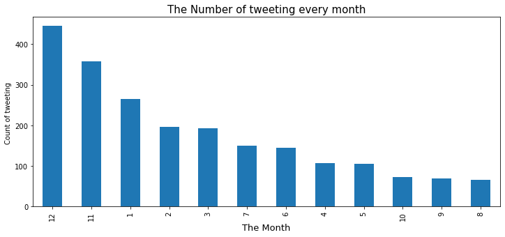

```python
twitter_archive_copy.month.value_counts().plot(kind='bar',figsize =(12,5))
plt.title("The Number of tweeting every month",fontsize =15)
plt.xlabel("The Month",fontsize = 13)
plt.ylabel("Count of tweeting ")
```

### The highest rate of tweets in the year is the last two months (11 and 12)

> . In general we can see that last 2 month have a highest rate  
> . Then comes the beginning of the year in January and February  
> . Month 8 and 9 have the lowest tweet rate

# >>>>>>>>>>>>>>>>>>>>>>>

## 2. Is there relationship between the stage of dogs and the rating

```python
stage_rating =twitter_archive_copy.groupby('stage')['rating'].mean()
```

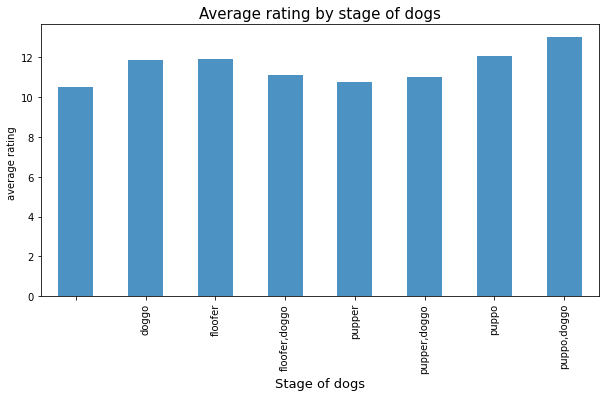

```python
stage_rating.plot(kind='bar',alpha=.8 , figsize=(10,5))
plt.title("Average rating by stage of dogs",fontsize =15)
plt.xlabel("Stage of dogs",fontsize = 13)
plt.ylabel("average rating ")
```

# >>>>>>>>>>>>>>>>>>>>>

## What is the most frequent rating?

```python
base_color = sb.color_palette()[0]
```

```python
ord_rate =twitter_archive_copy.rating.value_counts().index
```

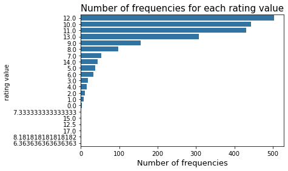

```python
sb.countplot(data=twitter_archive_copy ,y='rating',color=base_color , order =ord_rate)
plt.title("Number of frequencies for each rating value",fontsize =15)
plt.xlabel("Number of frequencies",fontsize = 13)
plt.ylabel("rating value ")
```

### The highest rating is 12, after that comes 10 .

### This shows how much they love dogs

# >>>>>>>>>>>>>>>>>>>>>

```python
image.head()
image.query('p1=="Golden_retriever"')
```

|  | tweet_id | jpg_url | img_num | p1 | p1_conf | p1_dog | p2 | p2_conf | p2_dog | p3 | p3_conf | p3_dog |
| --- | --- | --- | --- | --- | --- | --- | --- | --- | --- | --- | --- | --- |
| 495 | 675740360753160193 | https://pbs.twimg.com/ext_tw_video_thumb/67574... | 1 | Golden_retriever | 0.800495 | True | Golden_retriever | 0.097756 | True | Golden_retriever | 0.068415 | True |
| 1290 | 751456908746354688 | https://pbs.twimg.com/ext_tw_video_thumb/75145... | 1 | Golden_retriever | 0.714409 | True | Golden_retriever | 0.066163 | True | Golden_retriever | 0.028413 | True |
| 1574 | 795464331001561088 | https://pbs.twimg.com/ext_tw_video_thumb/79546... | 1 | Golden_retriever | 0.193082 | True | Golden_retriever | 0.157927 | True | Golden_retriever | 0.124684 | True |
| 1933 | 859607811541651456 | https://pbs.twimg.com/media/C-3wvtxXcAUTuBE.jpg | 1 | Golden_retriever | 0.895529 | True | Golden_retriever | 0.024099 | True | Golden_retriever | 0.019285 | True |
| 1923 | 857029823797047296 | https://pbs.twimg.com/media/C-TIEwMW0AEjb55.jpg | 2 | Golden_retriever | 0.968623 | True | Golden_retriever | 0.010325 | True | Golden_retriever | 0.004148 | True |
| ... | ... | ... | ... | ... | ... | ... | ... | ... | ... | ... | ... | ... |
| 2031 | 883117836046086144 | https://pbs.twimg.com/media/DEF2-_hXoAAs62q.jpg | 2 | Golden_retriever | 0.949562 | True | Golden_retriever | 0.045948 | True | Golden_retriever | 0.002471 | True |
| 2033 | 883482846933004288 | https://pbs.twimg.com/media/DELC9dZXUAADqUk.jpg | 1 | Golden_retriever | 0.943082 | True | Golden_retriever | 0.032409 | True | Golden_retriever | 0.005501 | True |
| 2057 | 888804989199671297 | https://pbs.twimg.com/media/DFWra-3VYAA2piG.jpg | 1 | Golden_retriever | 0.469760 | True | Golden_retriever | 0.184172 | True | Golden_retriever | 0.073482 | True |
| 2058 | 888917238123831296 | https://pbs.twimg.com/media/DFYRgsOUQAARGhO.jpg | 1 | Golden_retriever | 0.714719 | True | Golden_retriever | 0.120184 | True | Golden_retriever | 0.105506 | True |
| 2060 | 889531135344209921 | https://pbs.twimg.com/media/DFg_2PVW0AEHN3p.jpg | 1 | Golden_retriever | 0.953442 | True | Golden_retriever | 0.013834 | True | Golden_retriever | 0.007958 | True |

113 rows × 12 columns

# What kind of dog more frequency?

```python
dogs_more_frequancy= image.p1.value_counts()[:10]
dogs_more_frequancy
```

```
Golden_retriever      113
Pembroke               81
Labrador_retriever     78
Chihuahua              58
Pug                    45
Chow                   31
Pomeranian             31
Toy_poodle             30
Samoyed                26
Malamute               26
Name: p1, dtype: int64
```

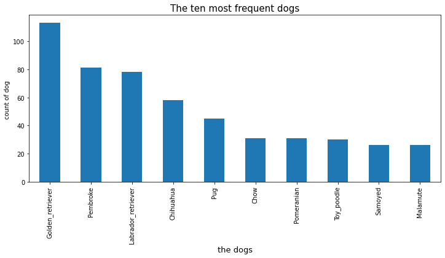

```python
dogs_more_frequancy.plot(kind='bar',figsize=(12,5))
plt.title("The ten most frequent dogs",fontsize =15)
plt.xlabel("the dogs",fontsize = 13)
plt.ylabel("count of dog ")
```

### The most frequent dog is Golden ( *Golden_retriever* ) after that coming ( *Pembroke* )

```python
image.query('p1 =="Pembroke"');
```

```python
url = image.jpg_url[2060]
r = requests.get(url)
Image.open(BytesIO(r.content))
```

[output not shown]

## image for the secound most frequent dog (Pembroke )

[figure not shown]

```python
url = image.jpg_url[1929]
r = requests.get(url)
Image.open(BytesIO(r.content))
```

# >>>>>>>>>>>>>>>>>>

```python
tweet_data.head(1)
```

|  | tweet_id | retweet_count | favorite_count |
| --- | --- | --- | --- |
| 0 | 892420643555336193 | 8853 | 39467 |

## Do you have a relationship between the rate of tweets and likes?

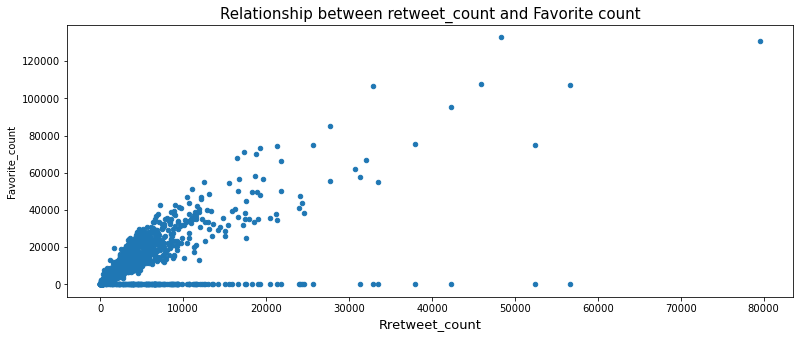

```python
tweet_data_copy.plot.scatter(x='retweet_count', y='favorite_count', figsize=(13,5));
plt.title("Relationship between retweet_count and Favorite count",fontsize =15)
plt.xlabel("Rretweet_count",fontsize = 13)
plt.ylabel("Favorite_count ")
```

### It seems that there is a positive relationship between the two

# Conclusions

### 1. The highest rate of tweets in the year is the last two months (11 and 12)

> . In general we can see that last 2 month have a highest rate  
> . Then comes the beginning of the year in January and February  
> . Month 8 and 9 have the lowest tweet rate

### 3. The highest rating is 12, after that comes 10 . This shows how much they love dogs

### 4. The most frequent dog is Golden ( *Golden_retriever* ) after that coming ( *Pembroke* )

### 5. there are positive relationship between retweet and favorite count

# References¶

1. [stack_over_flow](https://stackoverflow.com/)
2. [panda](https://pandas.pydata.org/)